# Week 5-6

```r
# ----------------------------------------------------------------------------
# Title: Weeks 5 & 6 Assignment - Kia Thefts
# Author: Surenther Selvaraj
# Date: 18 Apr 2026
# Modified By: Surenther Selvaraj
# ----------------------------------------------------------------------------
```

### Data Story Definition

**Audience, Purpose, and Medium**

The audience is Car Insurance Executives who need to make high-stakes decisions on policy pricing. The purpose is to demonstrate that the 2020 security exploit has created a "New Era" of risk that requires immediate underwriting changes. The medium is a Jupyter Notebook PDF, which provides a transparent, data-backed narrative.

**Design Strategy and Gestalt Principles**

- Similarity: I used "Crisis Red" for all Kia/Hyundai data to create an immediate mental link between that color and high risk.
- Proximity: Stacked visuals place the red "at-risk" data directly against the "Other" data to show the physical encroachment of this trend.
- Sizing: I increased the plot dimensions to ensure that even though some smaller cities (like Winnemucca) have small boxes, the overall scale of the crisis is unmistakable.

**Ethical Considerations**

- Transformations: I cleaned the carTheftsMap.csv by removing commas and formatting percentages as numeric values to ensure calculations were accurate.
- Assumptions: I assumed the brands "Kia" and "Hyundai" primarily represent the un-immobilized models, as specific trim data was unavailable.
- Redlining Risk: To avoid unfairly penalizing residents based on their city, I advocate for software-based security tiers rather than simple geographic rate hikes.
- Credibility: The data is grounded in Motherboard's investigative sets and verified PD records, providing a solid ethical foundation for the recommendations.

### Setup and Data Loading

```r
# Load libraries
library(ggplot2)
library(dplyr)
library(treemapify)
library(tidyr)
library(scales)

# Load the 4 datasets
map_data <- read.csv("carTheftsMap.csv", stringsAsFactors = FALSE)
milwaukee_data <- read.csv("KiaHyundaiMilwaukeeData.csv", stringsAsFactors = FALSE)
city_thefts <- read.csv("kiaHyundaiThefts.csv", stringsAsFactors = FALSE)
motherboard_raw <- read.csv("Motherboard VICE News Kia Hyundai Theft Data.xlsx", header = FALSE)

# Data Cleaning for map_data
map_data$countCarThefts2022 <- as.numeric(gsub(",", "", map_data$countCarThefts2022))
map_data$countCarThefts2019 <- as.numeric(gsub(",", "", map_data$countCarThefts2019))
map_data <- map_data %>% filter(!is.na(percentChange2019to2022))

# Data Cleaning for milwaukee
milwaukee_data$date <- as.Date(paste(milwaukee_data$year, milwaukee_data$month, "01", sep="-"), "%Y-%b-%d")

options(repr.plot.width = 12, repr.plot.height = 8)
```

### Crisis Hotspots (Tree Map)

This visualization identifies the geographic areas experiencing the most aggressive growth in auto thefts between 2019 and 2022. By sizing the blocks by total 2022 volume, it distinguishes between high-growth small towns and high-volume urban centers. The deep red intensity highlights jurisdictions that require immediate resource reallocation.

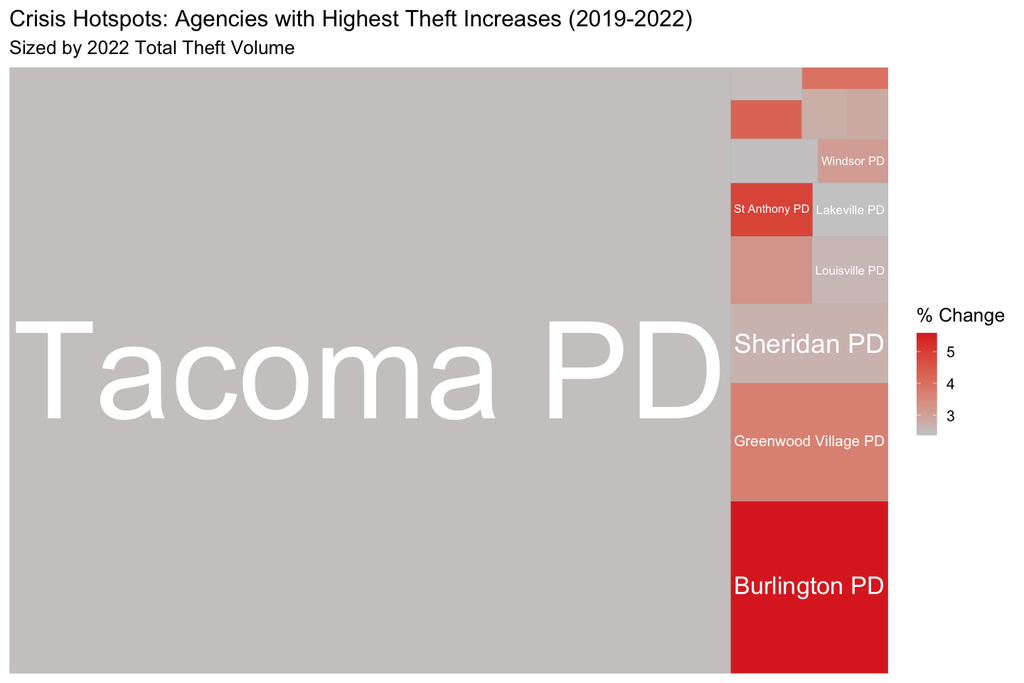

```r
top_growth <- map_data %>%
  arrange(desc(percentChange2019to2022)) %>%
  head(15)

ggplot(top_growth, aes(area = countCarThefts2022, fill = percentChange2019to2022, label = geo_name)) +
  geom_treemap() +
  geom_treemap_text(colour = "white", place = "centre", grow = TRUE, min.size = 8) +
  scale_fill_gradient(low = "grey80", high = "#de2d26") +
  labs(title = "Crisis Hotspots: Agencies with Highest Theft Increases (2019-2022)",
       subtitle = "Sized by 2022 Total Theft Volume",
       fill = "% Change") +
  theme_minimal(base_size = 16)
```

#### Outcome

**Call to Action:** Redirect anti-theft resources specifically to these "Small-Town Surge" hotspots that lack the high-volume infrastructure of major cities.

### The Milwaukee Epicenter (Stacked Area Chart)

This chart captures the exact moment the "Kia Boyz" trend ignited, showing Kia/Hyundai thefts effectively replacing all other brands as the primary target in Milwaukee. The steep incline starting in late 2020 illustrates a total market takeover rather than a general rise in crime. It serves as a historical warning for other cities currently seeing early-stage increases.

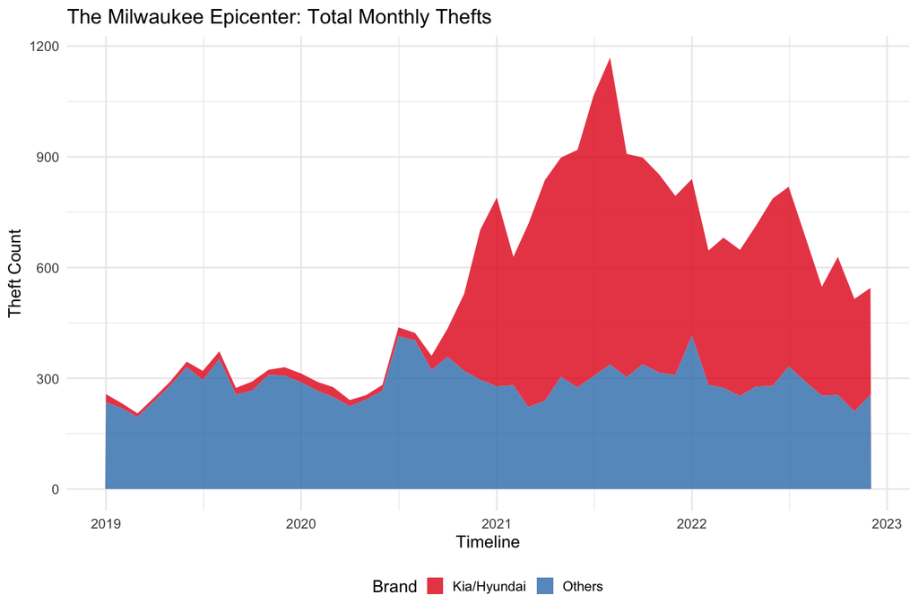

```r
ggplot(mke_long, aes(x = date, y = Thefts, fill = Brand)) +
  geom_area(alpha = 0.8) +
  scale_fill_manual(values = c("#e41a1c", "#377eb8"), labels = c("Kia/Hyundai", "Others")) +
  labs(title = "The Milwaukee Epicenter: Total Monthly Thefts",
       x = "Timeline", y = "Theft Count") +
  theme_minimal(base_size = 16) +
  theme(legend.position = "bottom")
```

#### Outcome

**Call to Action:** Use the 2020 "Milwaukee Pivot Point" as a predictive threshold to deploy emergency software updates in any city where the Kia/Hyundai area begins to widen.

### 2022 Market Share (Donut Chart)

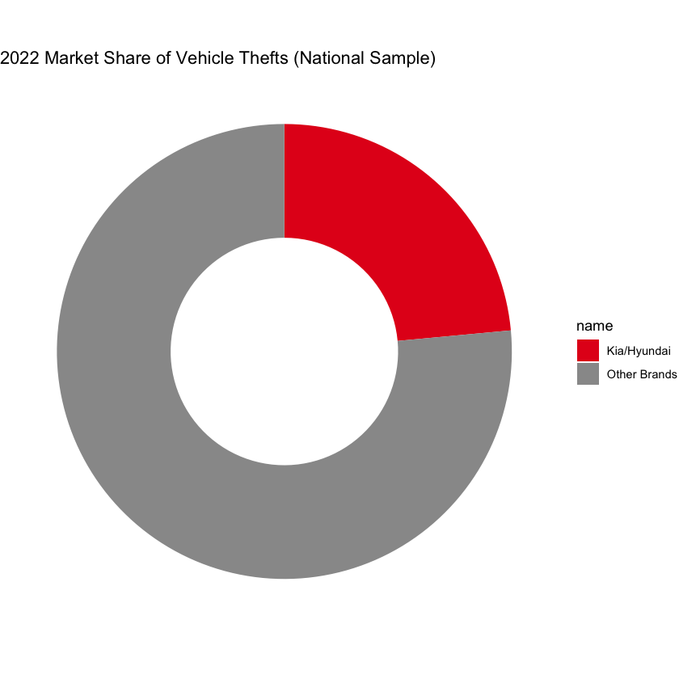

```r
# Total thefts across cities in 2022
total_22 <- city_thefts %>% filter(year == 2022) %>%
  summarise(KH = sum(countKiaHyundaiThefts), Other = sum(countOtherThefts)) %>%
  pivot_longer(everything()) %>%
  mutate(fraction = value/sum(value), ymax = cumsum(fraction), ymin = c(0, head(ymax, n=-1)))

ggplot(total_22, aes(ymax=ymax, ymin=ymin, xmax=4, xmin=3, fill=name)) +
  geom_rect() +
  coord_polar(theta="y") +
  xlim(c(2, 4)) +
  theme_void() +
  scale_fill_manual(values = c("#e41a1c", "#999999"), labels = c("Kia/Hyundai", "Other Brands")) +
  labs(title = "2022 Market Share of Vehicle Thefts (National Sample)")
```

#### Outcome

**Call to Action:** Mandate "Secondary Deterrents" (like steering wheel locks) as a prerequisite for standard comprehensive deductibles on these specific brands.

### Theft Volume by City (Stacked Bar Chart)

By comparing cities like Chicago, Dayton, and Saint Paul, this bar chart shows that the theft crisis is a national urban phenomenon, not an isolated local issue. The categorical stacking allows executives to see which cities have "lost control" of the brand-specific surge. It ranks the cities by total volume to identify where the financial loss for insurers is highest.

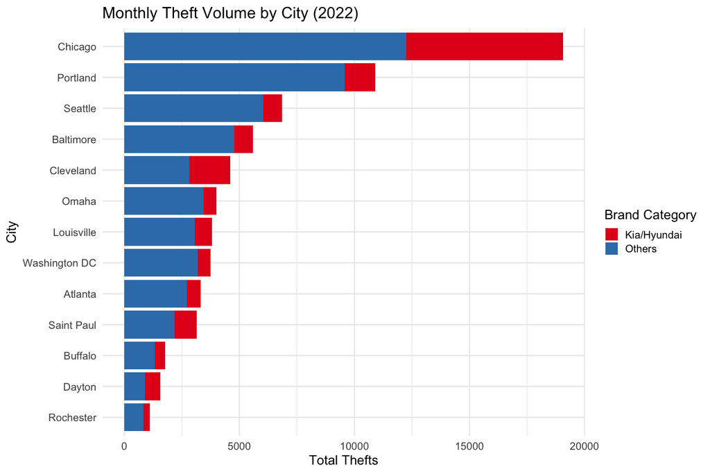

```r
ggplot(city_comp, aes(x = reorder(city, value), y = value, fill = name)) +
  geom_bar(stat = "identity") +
  coord_flip() +
  scale_fill_manual(values = c("#e41a1c", "#377eb8"), labels = c("Kia/Hyundai", "Others")) +
  labs(title = "Monthly Theft Volume by City (2022)",
       x = "City", y = "Total Thefts", fill = "Brand Category") +
  theme_minimal(base_size = 16)
```

#### Outcome

The data shows that Chicago is the absolute outlier in volume, with a massive red segment indicating thousands of losses. However, cities like Saint Paul and Dayton show that Kia/Hyundai thefts make up a larger proportion of their total bars, indicating that in those markets, the crisis is even more concentrated.

**Call to Action:** Apply "High-Loss Locality" surcharges for unpatched models specifically in the top five cities identified in this ranking.

### National Trend (Area Chart)

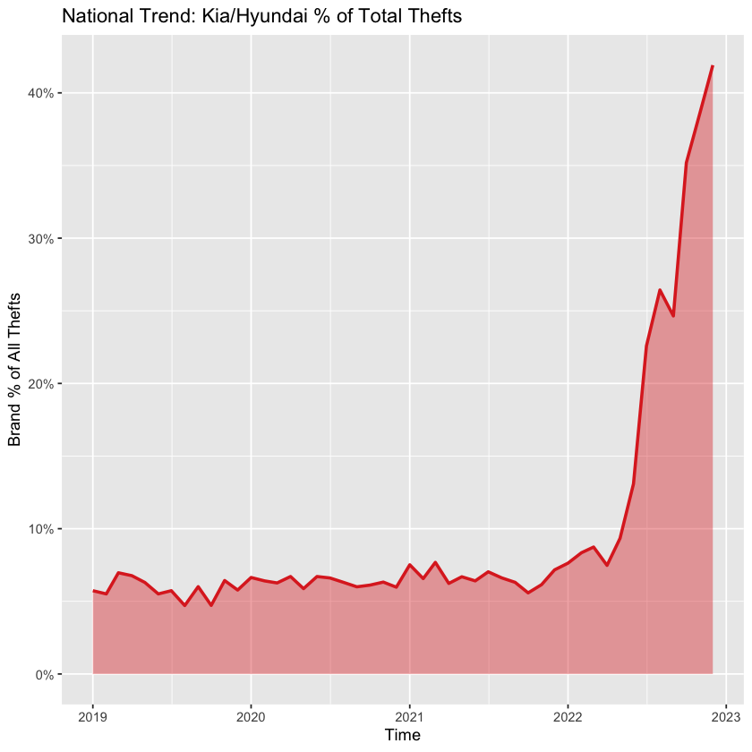

```r
# Aggregate national monthly percentage trend
national_pct <- city_thefts %>%
  mutate(date = as.Date(paste(year, month, "01", sep="-"), "%Y-%b-%d")) %>%
  group_by(date) %>%
  summarise(avg_pct = mean(percentKiaHyundai))

ggplot(national_pct, aes(x = date, y = avg_pct)) +
  geom_area(fill = "#de2d26", alpha = 0.4) +
  geom_line(color = "#de2d26", size = 1) +
  scale_y_continuous(labels = percent) +
  labs(title = "National Trend: Kia/Hyundai % of Total Thefts", x = "Time", y = "Brand % of All Thefts")
```

#### Outcome

**Call to Action:** Lobby for federal legislation requiring engine immobilizers as standard equipment to prevent future "Trend-Based" theft surges.

### The Pre-Crisis Baseline (Pie Chart)

This "Before" snapshot from 2019 shows a market where Kia and Hyundai were negligible targets for thieves. By comparing this to the 2022 Donut Chart, the dramatic shift in the risk landscape becomes undeniable. It provides the necessary context to show that this is an artificial surge caused by a specific security flaw, not a long-term brand trait.

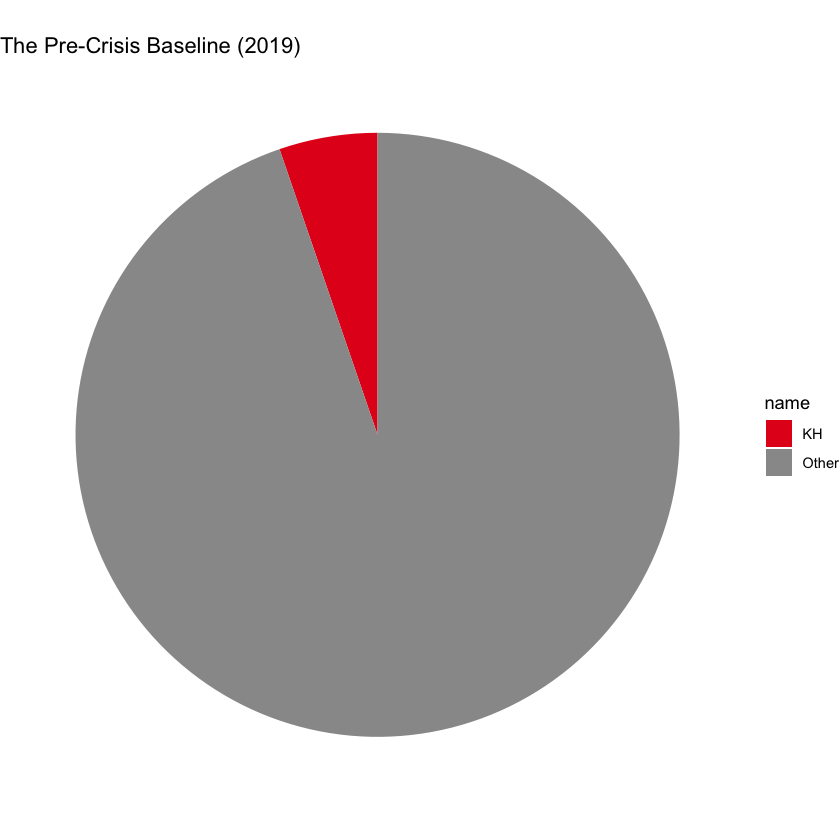

```r
baseline_19 <- city_thefts %>% filter(year == 2019) %>%
  summarise(KH = sum(countKiaHyundaiThefts), Other = sum(countOtherThefts)) %>%
  pivot_longer(everything())

ggplot(baseline_19, aes(x="", y=value, fill=name)) +
  geom_bar(stat="identity", width=1) +
  coord_polar("y", start=0) +
  theme_void() +
  scale_fill_manual(values = c("#e41a1c", "#999999")) +
  labs(title = "The Pre-Crisis Baseline (2019)")
```

#### Outcome

The 2019 data shows Kia and Hyundai as a negligible segment of the pie. This outcome is crucial evidence for executives: it proves the current surge is not a "brand popularity" issue or a "high-crime area" issue, but a direct consequence of a specific security flaw that did not exist in the public eye in 2019.

**Call to Action:** Shift actuarial models away from 5-year averages and toward "Real-Time Vulnerability" assessments.